# Explaining an Autonomous Agent’s Choices

erindb

```r
knitr::opts_chunk$set(echo=F, warning=F, message=F)
```

```
## [1] "installing webppl"
```

## Central Example

Suppose an agent is choosing between 3 gifts: some kind of ugly but delicious brownies, some pretty but inedible flowers, and some adorable and delicious cupcakes. Here are these gifts in a 2D feature space of prettiness and yumminess:

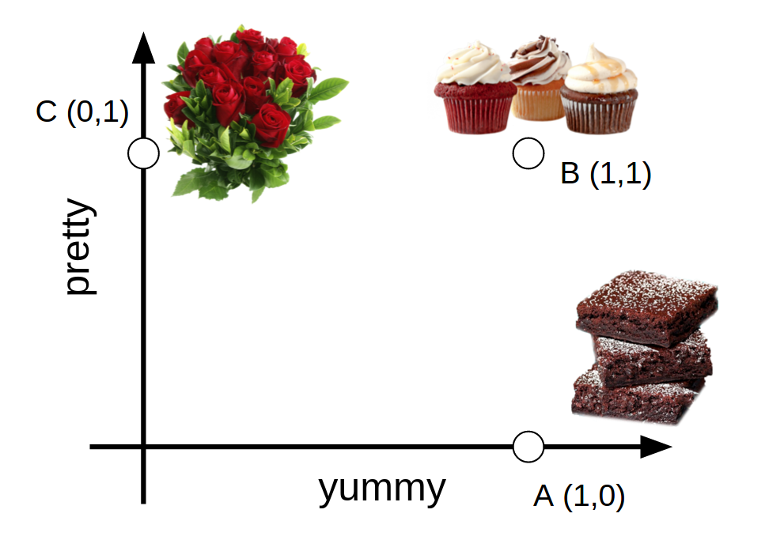

Here are 4 possible utility functions that the agent could have and their corresponding distributions over choices.

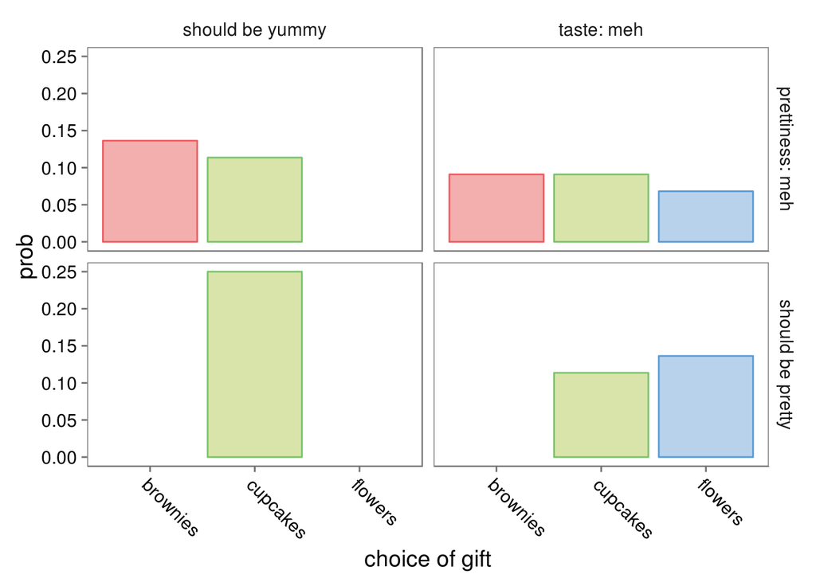

Now given a particular gift choice made under a particular utility function, we can ask which terms in the utility function were most reponsible for the agent’s selection.

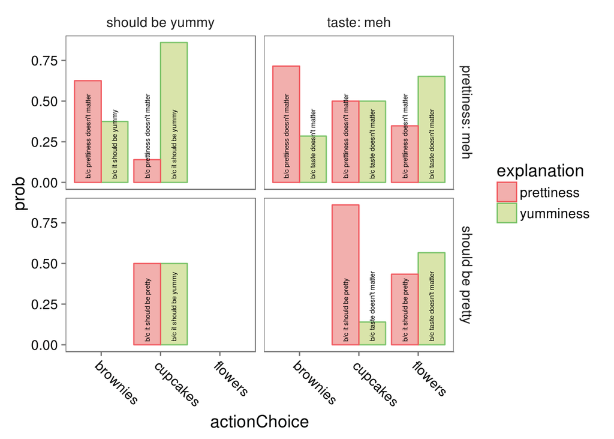

In general, if we pick an option that’s high in one of the dimensions we care about, we tend to explain choosing it with, “Because I care about the dimension it’s good on.” When we pick an options that’s low on a dimension we don’t care about, we explain choosing it with, “Because I don’t care about the dimension it’s low on.” Because of our high rationality, we never pick anything that’s low on a dimension we care about.

So this is one simple example that seems to have the kind of behavior I expect. Let’s increase the complexity. There are many choices of where to go from here. I’ll list a few:

- modify the options
  - add an option at the origin
    - this will probably lead to a lot more symmetry, which might result in counterintuitively equally probable explanations
  - add multiple options at a particular point in feature space
  - subtract one or more options from the set of considered options
  - add options with fractional values in feature space
- change the possible utility functions
  - utility coefficients of features can be negative
  - certain coefficients are more likely than others
  - coeficients can have different magnitudes
- change the number of features
  - try 3 features next
- open up agent’s choices to more randomness
  - lower rationality
  - uncertainty about action outcomes (noisy consequences of actions)
  - multi-step action planning, i.e. some choices open up other future choices
    - e.g. have a map we can move through with different transition probabilities

## 3D Feature Space Example

Probably the simplest change to make is increasing the feature space to 3 dimensions. Let’s add a “long-lasting” dimension.

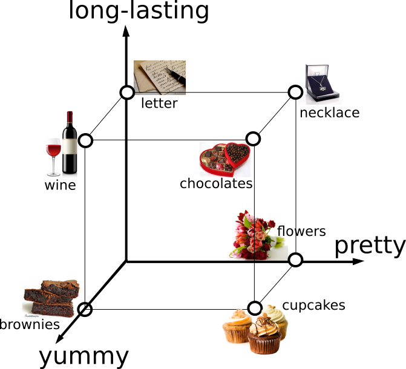